# Chapter 10 Applied Exercise 8

Josh Stead, Kate Dedrick, Michael Waters, Jia Chen

3/30/2021

## Calculating PVE With Model Output

As in Lab 10.4, we read in our data and create a principal components model, using the scale = TRUE argument to center and scale our data with a mean of 0 and a standard deviation of 1.

```r
data(USArrests)

pr.out=prcomp(USArrests , scale=TRUE)
```

As shown, the prcomp() function outputs the standard deviation of each principal component, which we can square to get the variance of each component and divide by the total variance to get the percentage of variance explained by each component (PVE).

```r
pr.var=pr.out$sdev ^2

PVE = pr.var / sum(pr.var)
PVE = round(PVE,3)

PVE_matrix <- as.matrix(cbind(PVE[1], PVE[2], PVE[3], PVE[4]))
colnames(PVE_matrix) <- c('PC1', 'PC2', 'PC3', 'PC4')
rownames(PVE_matrix) <- 'PVE'
PVE_matrix
```

```
##      PC1   PC2   PC3   PC4
## PVE 0.62 0.247 0.089 0.043
```

## Calculating PVE Using Textbook Equation

We can also calculate PVE according to the equation below (from page 383 in the textbook). The numerator of the equation denotes the variance explained by each component m, and the denominator denotes the total variance in the data set.

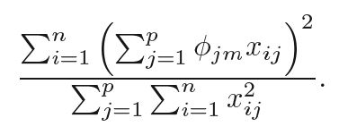

First, we calculate the denominator of the equation, the total variance in the model. We calculate variance by squaring the distances of each observation from the mean for each feature in the data set. Since our data set is scaled, i.e. the mean of each parameter is zero, we can simply square each value in the data set and sum them together.

```r
USArrests <- scale(USArrests)

sum_var = 0
for (j in 1:4) {
  for (i in 1:50) {
    sum_var = sum_var + USArrests[i,j]^2
  }
}
sum_var
```

```
## [1] 196
```

Next, we calculate the numerator of the equation, the amount of variance explained by each principal component. First, we retrieve the loadings for each component. Then, for each component, we run through every observation in the data set, multiplying each observation’s value for each feature by the element of the component’s loading corresponding to that feature and summing the result (this is the portion of the numerator inside the parentheses). To get the total amount of variance explained by each component, We sum the result of this process for every observation in the data set.

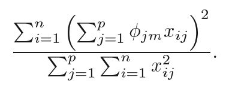

```r
loadings <- pr.out$rotation

PVE2 = rep(0, 4)
for (m in 1:4) {
  for (i in 1:50) {
    result = 0
    for (j in 1:4) {
      result = result + loadings[j,m]*USArrests[i,j]
    }
    PVE2[m] = PVE2[m] + result^2
  }
  PVE2[m] = round(PVE2[m] / sum_var, 3)
}

PVE2_matrix <- as.matrix(cbind(PVE2[1], PVE2[2], PVE2[3], PVE2[4]))
colnames(PVE2_matrix) <- c('PC1', 'PC2', 'PC3', 'PC4')
rownames(PVE2_matrix) <- 'PVE'
PVE2_matrix
```

```
##      PC1   PC2   PC3   PC4
## PVE 0.62 0.247 0.089 0.043
```

## Faster Method for Calculating PVE

Using loops to do these calculations helps to visualize the textbook equation, but we can vastly simplify our code and achieve the same result using the apply() function and matrix multiplication.

```r
sum_var <- sum(apply(as.matrix(USArrests)^2, 2, sum))
PVE3 <- apply((as.matrix(USArrests) %*% loadings)^2, 2, sum) / sum_var
PVE3 <- round(PVE3, 3)

PVE3_matrix <- as.matrix(cbind(PVE3[1], PVE3[2], PVE3[3], PVE3[4]))
colnames(PVE3_matrix) <- c('PC1', 'PC2', 'PC3', 'PC4')
rownames(PVE3_matrix) <- 'PVE'
PVE3_matrix
```

```
##      PC1   PC2   PC3   PC4
## PVE 0.62 0.247 0.089 0.043
```